# TSS_analysis_bvw_initial

Sarah Hazell Pickering

2024-04-11

```r
library(BPCells)
library(RColorBrewer)
library(Seurat)
library(clusterProfiler)
library(dplyr)
library(enrichplot)
library(ggplot2)
library(ggsci)
library(here)
library(patchwork)
```

```r
module = "beige_vs_white"
dataname = "tss_bvw_initial"
load_data = F #load unfiltered seurat object from previous analysis?
subset_data = F

rmd_filename = "tss_bvw_initial"
i_am(file.path("analysis", module, paste0(rmd_filename,".Rmd")))
```

```
## here() starts at /projects/imb-pkbphil/sp/sc_rnaseq/progenitor_scrnaseq
```

```r
odir = here("output", module, dataname)
indir = here("data/scafe/count/day0_to_day3_rep1")
```

```r
set.seed(8)
fig_dir = here("analysis", module, "figures", rmd_filename)
if (!dir.exists(fig_dir)) dir.create(fig_dir, recursive = TRUE)
knitr::opts_chunk$set(fig.path = paste0(fig_dir, "/"),
                      dev = c("png","pdf"))

if (!dir.exists(odir)) dir.create(odir, recursive = TRUE)
```

```r
theme_hp = theme_classic(base_size = 15) +
  theme(axis.line = element_line(linewidth = 0.25),
        axis.ticks = element_line(linewidth = 0.25),
        strip.background = element_blank())
theme_set(theme_hp)
pal = c("#1F78B4", "#85C2EA","#B3B3B3", "#F18486","#E31A1C")
clusters = tvthemes::gravityFalls_pal()(13)
spectral = rev(RColorBrewer::brewer.pal(n = 11, name = 'Spectral'))
```

## Read data

Can start from counts if load_data=FALSE, or work on a subset if subset_data=T

```r
samples = list.dirs(here(indir), full.names = F, recursive = F)

if (load_data==FALSE){# load count matrices

  data_list = c()

  for (s in samples){
    #if this has been run before delete bp dir
    bc_matrix = Read10X(data.dir = here(indir, s, "matrix"))
    so = CreateSeuratObject(counts=bc_matrix, project=s, names.field = 2, names.delim = "-")
    write_matrix_dir(mat=so[["RNA"]]$counts, dir = here(odir, "bpcells", s))
    gene_mat = open_matrix_dir(here(odir, "bpcells", s))
    so[["RNA"]]$counts = gene_mat

    data_list = c(data_list,so)
  }
  names(data_list) = samples
  aggr = merge(data_list[[1]], y= data_list[2:length(data_list)],
               add.cell.ids = gsub("_",".",samples), project="day0_to_day3" )

  saveRDS(aggr,here(odir, "unfiltered_object.rds"))


  rm(data_list, bc_matrix, so)
} else if(load_data){
  aggr = readRDS(here(odir, "unfiltered_object.rds"))
}
aggr
```

```
## An object of class Seurat
## 75117 features across 41953 samples within 1 assay
## Active assay: RNA (75117 features, 0 variable features)
##  5 layers present: counts.asc_day0, counts.beige_day1, counts.beige_day3, counts.white_day1, counts.white_day3
```

```r
head(aggr@meta.data) #auto metadata
```

```
##                             orig.ident nCount_RNA nFeature_RNA
## asc.day0_AAACCTGAGAATAGGG-1          1      28336         5233
## asc.day0_AAACCTGAGAGGGCTT-1          1      37024         6468
## asc.day0_AAACCTGAGATCGATA-1          1      28539         5268
## asc.day0_AAACCTGAGGTAGCTG-1          1      21231         4587
## asc.day0_AAACCTGAGGTGCTAG-1          1      25659         5537
## asc.day0_AAACCTGAGTTGTAGA-1          1      29639         5930
```

```r
aggr$orig.ident = gsub("\\.","_",gsub("_.*", "",rownames(aggr@meta.data)))
aggr$orig.ident = factor(aggr$orig.ident, levels = c("white_day3","white_day1","asc_day0","beige_day1","beige_day3"))
Idents(aggr) = aggr$orig.ident
table(aggr@meta.data$orig.ident)
```

```
##
## white_day3 white_day1   asc_day0 beige_day1 beige_day3
##      11628       6138       7553       2690      13944
```

```r
aggr$condition = gsub("_.*","", aggr$orig.ident)
table(aggr$condition)
```

```
##
##   asc beige white
##  7553 16634 17766
```

```r
aggr$time = gsub(".*_", "", gsub("asc_donor13","day0",aggr$orig.ident))
table(aggr$time)
```

```
##
##  day0  day1  day3
##  7553  8828 25572
```

```r
pal = c("#1F78B4", "#85C2EA","#B3B3B3", "#F18486","#E31A1C")
levels(aggr$orig.ident)
```

```
## [1] "white_day3" "white_day1" "asc_day0"   "beige_day1" "beige_day3"
```

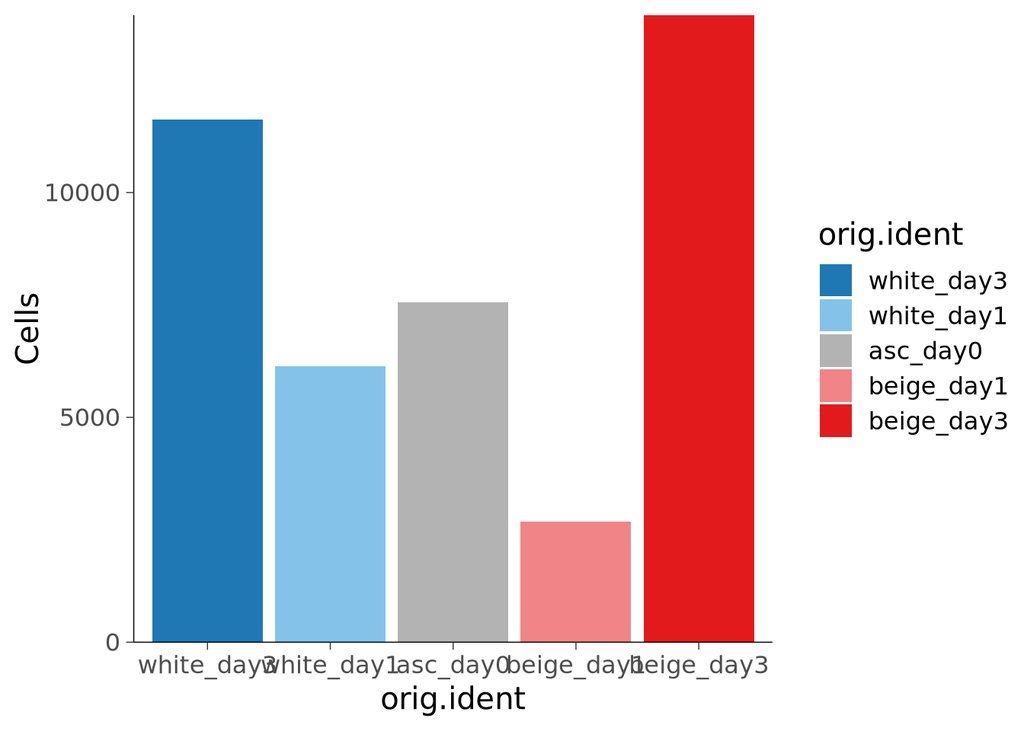

```r
ggplot(aggr@meta.data) + geom_bar(aes(x=orig.ident, fill=orig.ident)) +
  scale_fill_manual(values=pal) + scale_y_continuous(expand=c(0,0), name="Cells")
```

### Merge layers for straight-forward analysis

```r
aggr <- JoinLayers(aggr)
aggr
```

```
## An object of class Seurat
## 75117 features across 41953 samples within 1 assay
## Active assay: RNA (75117 features, 0 variable features)
##  1 layer present: counts
```

```r
if (subset_data){
  aggr = subset(aggr, downsample=1000)
  print(aggr)
}
```

## CRE format

for annotated gene_promoters the gene name is listed after the @ (~ one third (25k) of CREs).

```r
head(Features(aggr))
```

```
## [1] "D:r1@ADDG01000010954.R"
## [2] "P:r1@ADDG01000017342.F"
## [3] "D:r1@ADDG01000024899.R"
## [4] "P:r1@MIR1302-2HG,r2@ADDG01000029247.B"
## [5] "P:r1@ADDG01000029247.B,r1@WASH7P"
## [6] "D:r1@ADDG01000034827.F"
```

Simplify gene names on CREs - if there’s a gene name, ignore cluster-specific ids

```r
feature_metadata = data.frame(full_id = row.names(aggr[["RNA"]]), row.names = row.names(aggr[["RNA"]]),
                              simple_id = gsub("r[0-9]*@ADDG[0-9]*\\.[A-Z],","",
                                              gsub(",r[0-9]*@ADDG[0-9]*\\.[A-Z]$","",rownames(aggr[["RNA"]]))))
feature_metadata$gene_name = gsub("[DP]:r[0-9]*@", "", feature_metadata$simple_id)
feature_metadata$proximity = gsub(":r[0-9]*@.*", "", feature_metadata$simple_id)

aggr[["RNA"]] = AddMetaData(aggr[["RNA"]], feature_metadata)
row.names(aggr[["RNA"]]) = aggr[["RNA"]][["simple_id"]]$simple_id
head(aggr[["RNA"]])
```

```
##                                                      full_id
## D:r1@ADDG01000010954.R                D:r1@ADDG01000010954.R
## P:r1@ADDG01000017342.F                P:r1@ADDG01000017342.F
## D:r1@ADDG01000024899.R                D:r1@ADDG01000024899.R
## P:r1@MIR1302-2HG       P:r1@MIR1302-2HG,r2@ADDG01000029247.B
## P:r1@WASH7P                 P:r1@ADDG01000029247.B,r1@WASH7P
## D:r1@ADDG01000034827.F                D:r1@ADDG01000034827.F
## P:r1@ADDG01000036525.F                P:r1@ADDG01000036525.F
## D:r1@ADDG01000096655.F                D:r1@ADDG01000096655.F
## D:r1@ADDG01000181714.R                D:r1@ADDG01000181714.R
## P:r1@WASH9P                                      P:r1@WASH9P
##                                     simple_id         gene_name proximity
## D:r1@ADDG01000010954.R D:r1@ADDG01000010954.R ADDG01000010954.R         D
## P:r1@ADDG01000017342.F P:r1@ADDG01000017342.F ADDG01000017342.F         P
## D:r1@ADDG01000024899.R D:r1@ADDG01000024899.R ADDG01000024899.R         D
## P:r1@MIR1302-2HG             P:r1@MIR1302-2HG       MIR1302-2HG         P
## P:r1@WASH7P                       P:r1@WASH7P            WASH7P         P
## D:r1@ADDG01000034827.F D:r1@ADDG01000034827.F ADDG01000034827.F         D
## P:r1@ADDG01000036525.F P:r1@ADDG01000036525.F ADDG01000036525.F         P
## D:r1@ADDG01000096655.F D:r1@ADDG01000096655.F ADDG01000096655.F         D
## D:r1@ADDG01000181714.R D:r1@ADDG01000181714.R ADDG01000181714.R         D
## P:r1@WASH9P                       P:r1@WASH9P            WASH9P         P
```

```r
tail(aggr[["RNA"]])
```

```
##                                       full_id              simple_id
## P:r1@VAMP7                         P:r1@VAMP7             P:r1@VAMP7
## D:r1@ADDG0X155900517.R D:r1@ADDG0X155900517.R D:r1@ADDG0X155900517.R
## D:r1@ADDG0X156029412.F D:r1@ADDG0X156029412.F D:r1@ADDG0X156029412.F
## P:r1@EIF4A1P2                   P:r1@EIF4A1P2          P:r1@EIF4A1P2
## D:r1@ADDG0Y008446403.R D:r1@ADDG0Y008446403.R D:r1@ADDG0Y008446403.R
## P:r1@AC134878.2               P:r1@AC134878.2        P:r1@AC134878.2
## D:r1@ADDG0Y012497709.F D:r1@ADDG0Y012497709.F D:r1@ADDG0Y012497709.F
## P:r1@XGY1                           P:r1@XGY1              P:r1@XGY1
## P:r1@PSMA6P1                     P:r1@PSMA6P1           P:r1@PSMA6P1
## P:r1@AC012005.2               P:r1@AC012005.2        P:r1@AC012005.2
##                                gene_name proximity
## P:r1@VAMP7                         VAMP7         P
## D:r1@ADDG0X155900517.R ADDG0X155900517.R         D
## D:r1@ADDG0X156029412.F ADDG0X156029412.F         D
## P:r1@EIF4A1P2                   EIF4A1P2         P
## D:r1@ADDG0Y008446403.R ADDG0Y008446403.R         D
## P:r1@AC134878.2               AC134878.2         P
## D:r1@ADDG0Y012497709.F ADDG0Y012497709.F         D
## P:r1@XGY1                           XGY1         P
## P:r1@PSMA6P1                     PSMA6P1         P
## P:r1@AC012005.2               AC012005.2         P
```

```r
aggr[["RNA"]][[]]["P:r1@SAMD11",]
```

```
##                                                           full_id   simple_id
## P:r1@SAMD11 P:r1@ADDG01000924943.B,r1@ADDG01000925810.B,r1@SAMD11 P:r1@SAMD11
##             gene_name proximity
## P:r1@SAMD11    SAMD11         P
```

## Mito QC

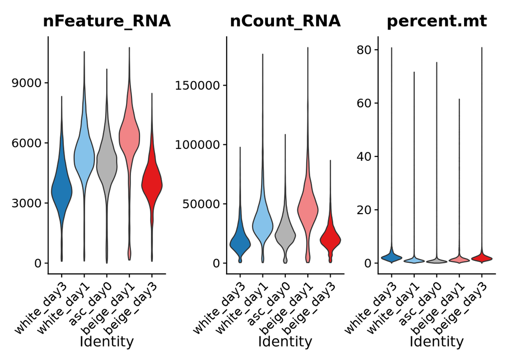

```r
aggr[["percent.mt"]] = PercentageFeatureSet(aggr, pattern="@MT-")
VlnPlot(aggr, features = c("nFeature_RNA", "nCount_RNA", "percent.mt"), ncol = 3, pt.size = 0, cols=pal)
```

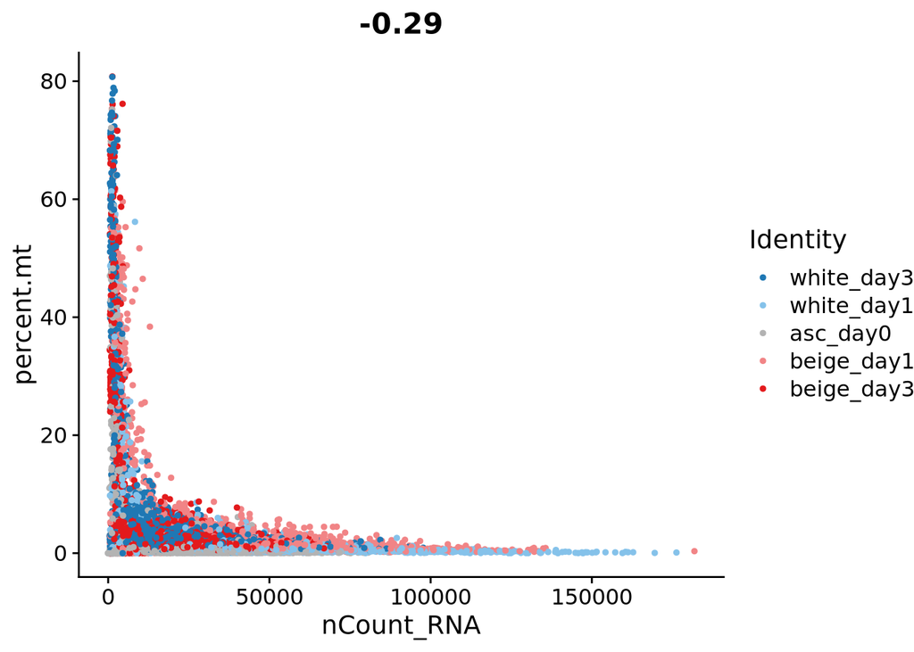

```r
FeatureScatter(aggr, feature1 = "nCount_RNA", feature2 = "percent.mt", cols=pal, shuffle=T)
```

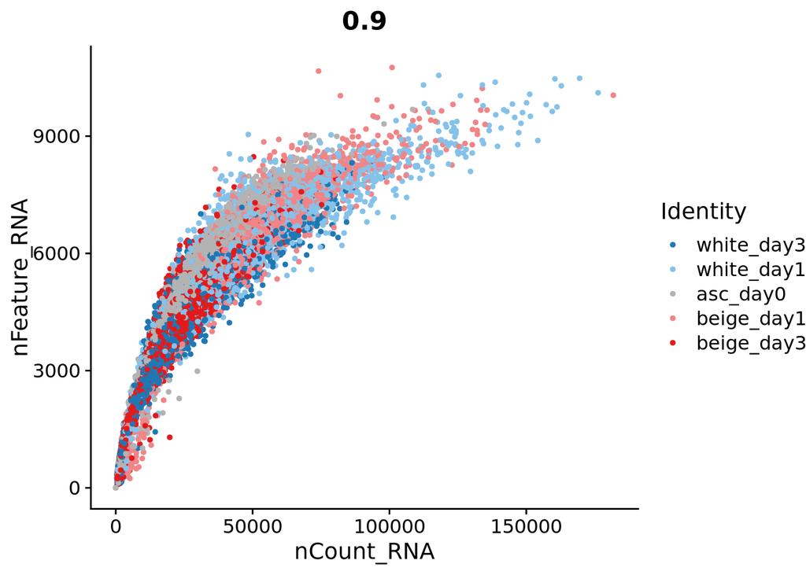

```r
FeatureScatter(aggr, feature1 = "nCount_RNA", feature2 = "nFeature_RNA", cols=pal, shuffle=T)
```

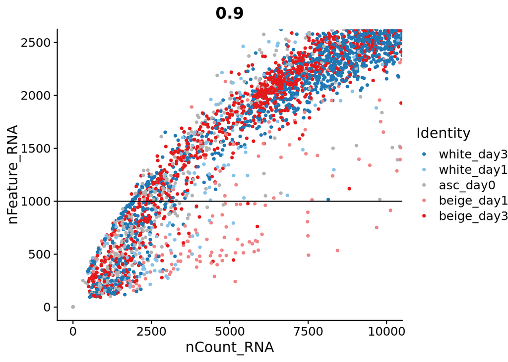

```r
FeatureScatter(aggr, feature1 = "nCount_RNA", feature2 = "nFeature_RNA", cols=pal, shuffle=T) +
  coord_cartesian(y=c(0,2500), x=c(0,10000)) + geom_hline(yintercept=1000)
```

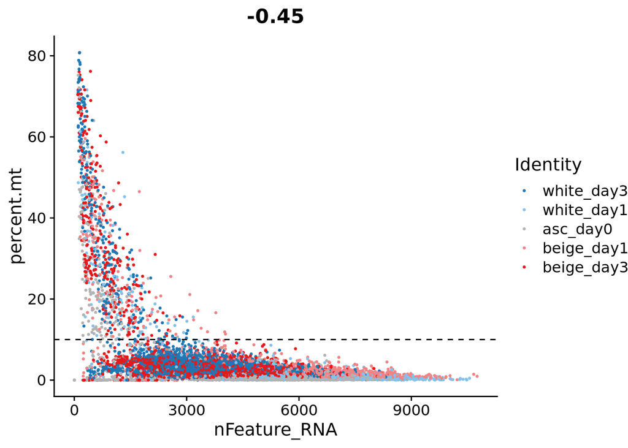

```r
FeatureScatter(aggr, feature1 = "nFeature_RNA", feature2 = "percent.mt", pt.size = 0.5, cols=pal, shuffle=T) +
  geom_hline(aes(yintercept=10), linetype="dashed")
```

### Final filter

Use the maximum 3*mad threshold

```r
mt_info = group_by(aggr@meta.data, orig.ident) %>%
  summarise(mad = mad(percent.mt),
            median = median(percent.mt),
            thresh = median(percent.mt) + mad(percent.mt)*3,
            th95 = quantile(percent.mt, 0.95))
mt_info
```

```
## # A tibble: 5 × 5
##   orig.ident   mad median thresh  th95
##   <fct>      <dbl>  <dbl>  <dbl> <dbl>
## 1 white_day3 0.960  2.16    5.04  5.48
## 2 white_day1 0.523  0.909   2.48  2.44
## 3 asc_day0   0.446  0.651   1.99  2.17
## 4 beige_day1 0.689  1.27    3.34  9.50
## 5 beige_day3 0.791  1.83    4.20  4.31
```

```r
thresh = max(mt_info$thresh)
thresh
```

```
## [1] 5.035872
```

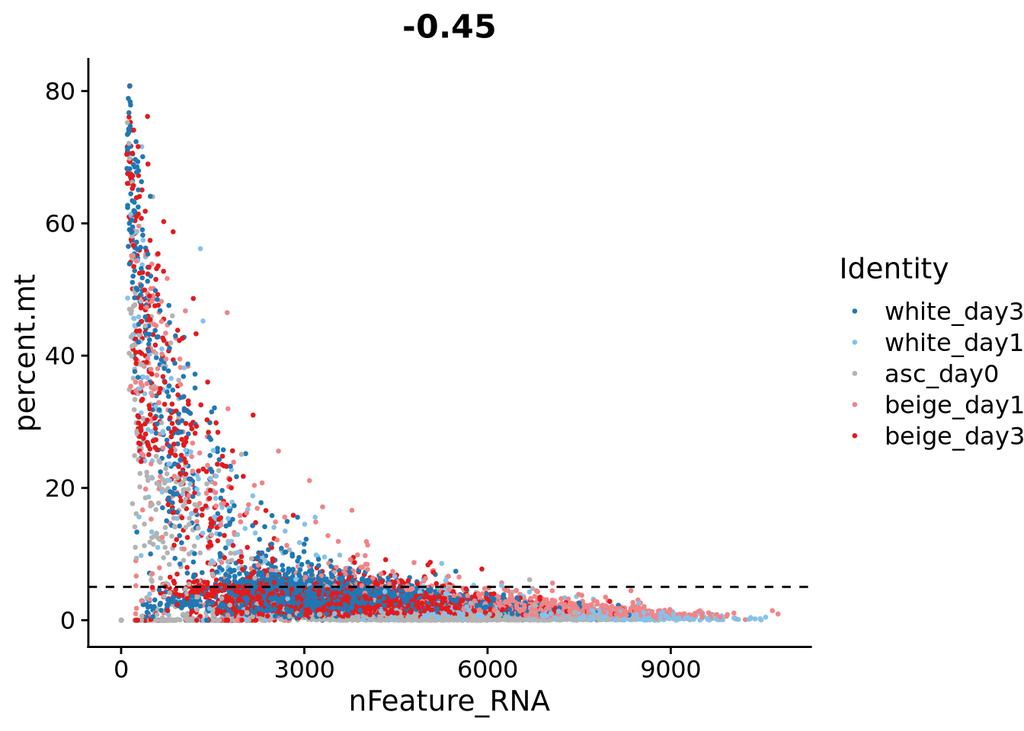

```r
FeatureScatter(aggr, feature1 = "nFeature_RNA", feature2 = "percent.mt", cols=pal, shuffle=T, pt.size = 0.5) +
  geom_hline(aes(yintercept=thresh), linetype="dashed")
```

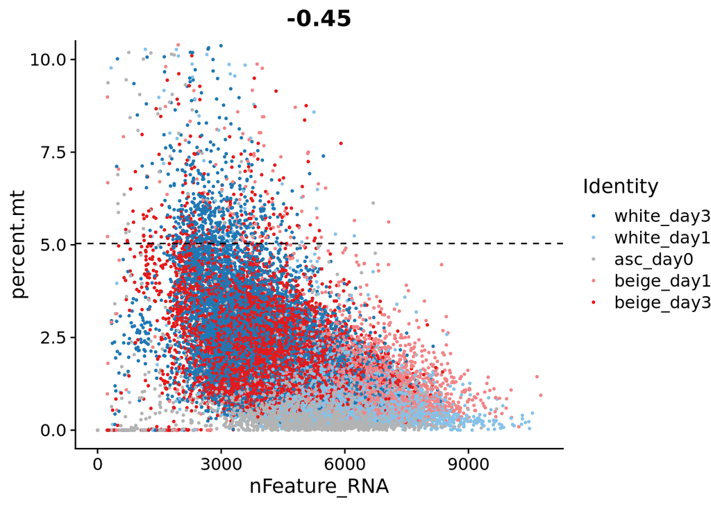

```r
FeatureScatter(aggr, feature1 = "nFeature_RNA", feature2 = "percent.mt", cols=pal, shuffle=T, pt.size = 0.5) +
  geom_hline(aes(yintercept=max(mt_info$thresh)), linetype="dashed") +coord_cartesian(ylim=c(0,10))
```

```r
filt = subset(aggr, subset = percent.mt < thresh & nFeature_RNA > 1000 )
filt #82Mb
```

```
## An object of class Seurat
## 75117 features across 40047 samples within 1 assay
## Active assay: RNA (75117 features, 0 variable features)
##  1 layer present: counts
```

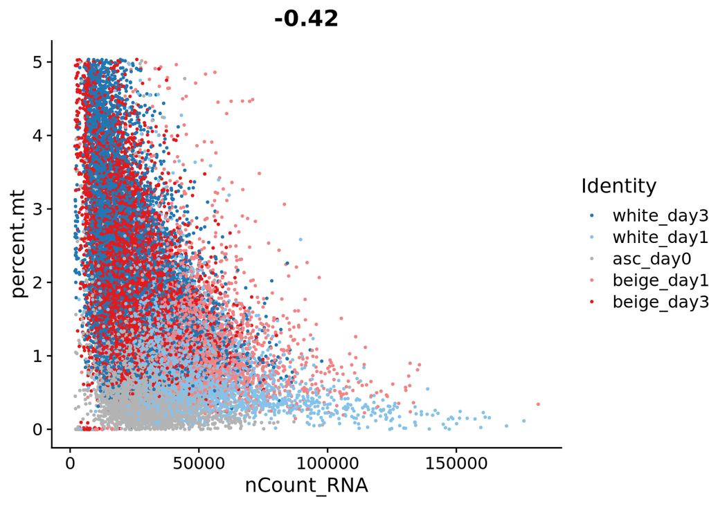

```r
FeatureScatter(filt, feature1 = "nCount_RNA", feature2 = "percent.mt", pt.size = 0.5, cols=pal, shuffle = T)
```

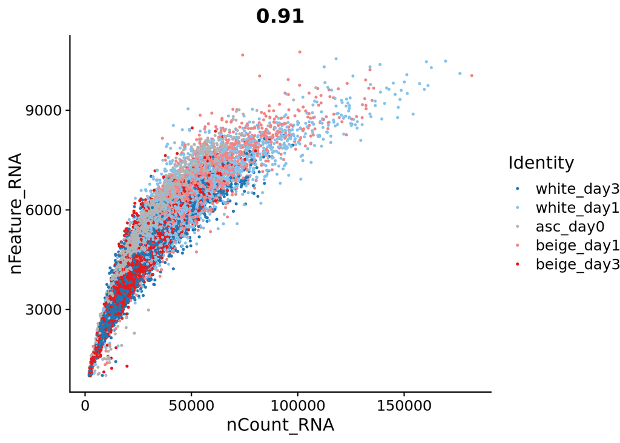

```r
FeatureScatter(filt, feature1 = "nCount_RNA", feature2 = "nFeature_RNA", pt.size = 0.5, cols=pal, shuffle=T)
```

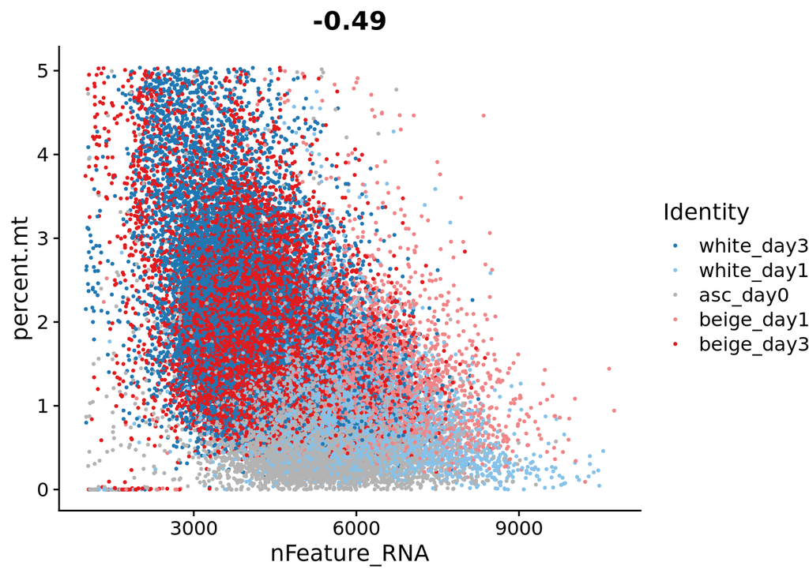

```r
FeatureScatter(filt, feature1 = "nFeature_RNA", feature2 = "percent.mt", pt.size = 0.5, cols=pal, shuffle=T)
```

```r
rm(aggr)
```

## Equalise cell numbers

Downsample to equalise cell numbers across conditions

```r
table(Idents(filt))
```

```
##
## white_day3 white_day1   asc_day0 beige_day1 beige_day3
##      10848       5988       7309       2459      13443
```

```r
filt$sample = filt$orig.ident
head(filt@meta.data)
```

```
##                             orig.ident nCount_RNA nFeature_RNA condition time
## asc.day0_AAACCTGAGAATAGGG-1   asc_day0      28336         5233       asc day0
## asc.day0_AAACCTGAGAGGGCTT-1   asc_day0      37024         6468       asc day0
## asc.day0_AAACCTGAGATCGATA-1   asc_day0      28539         5268       asc day0
## asc.day0_AAACCTGAGGTAGCTG-1   asc_day0      21231         4587       asc day0
## asc.day0_AAACCTGAGGTGCTAG-1   asc_day0      25659         5537       asc day0
## asc.day0_AAACCTGAGTTGTAGA-1   asc_day0      29639         5930       asc day0
##                             percent.mt   sample
## asc.day0_AAACCTGAGAATAGGG-1  0.7905138 asc_day0
## asc.day0_AAACCTGAGAGGGCTT-1  0.5563959 asc_day0
## asc.day0_AAACCTGAGATCGATA-1  0.3574057 asc_day0
## asc.day0_AAACCTGAGGTAGCTG-1  0.6499929 asc_day0
## asc.day0_AAACCTGAGGTGCTAG-1  1.6134690 asc_day0
## asc.day0_AAACCTGAGTTGTAGA-1  0.4453592 asc_day0
```

```r
ident_tab = group_by(filt@meta.data, time, condition,sample) %>% count()
ident_tab
```

```
## # A tibble: 5 × 4
## # Groups:   time, condition, sample [5]
##   time  condition sample         n
##   <chr> <chr>     <fct>      <int>
## 1 day0  asc       asc_day0    7309
## 2 day1  beige     beige_day1  2459
## 3 day1  white     white_day1  5988
## 4 day3  beige     beige_day3 13443
## 5 day3  white     white_day3 10848
```

```r
min_cells = group_by(ident_tab, time) %>% summarise(min=min(n))
min_cells
```

```
## # A tibble: 3 × 2
##   time    min
##   <chr> <int>
## 1 day0   7309
## 2 day1   2459
## 3 day3  10848
```

```r
temp_sbs = list()
for (time in min_cells$time){
  print(time)
  idents = ident_tab$sample[ident_tab$time == time]
  dwns = min_cells$min[min_cells$time == time]
  temp_sbs[[time]] = subset(filt, idents=idents, downsample =dwns)
}
```

```
## [1] "day0"
## [1] "day1"
## [1] "day3"
```

```r
sbs = merge(x=temp_sbs[[1]],y=temp_sbs[2:length(temp_sbs)])
sbs = JoinLayers(sbs)
sbs$sample = factor(sbs$sample, levels=levels(filt$sample))
sbs$orig.ident = sbs$sample
Idents(sbs) = "sample"
sbs$cond.time = paste0(sbs$condition,".", sbs$time )
sbs
```

```
## An object of class Seurat
## 75117 features across 33923 samples within 1 assay
## Active assay: RNA (75117 features, 0 variable features)
##  1 layer present: counts
```

```r
rm(filt)
```

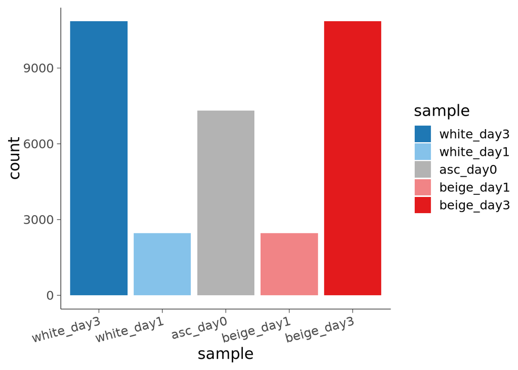

```r
ggplot(sbs@meta.data) + geom_bar(aes(x=sample, fill=sample)) + scale_fill_manual(values=pal) +
  theme(axis.text.x = element_text(angle=15, hjust=1))
```

## Basic Normalisation Scale the read depth

Feature counts for each cell are divided by the total counts for that cell and multiplied by the scale.factor. This is then natural-log transformed using log1p

```r
sbs= NormalizeData(sbs, normalization.method = "LogNormalize", scale.factor = 10000)
```

```
## Normalizing layer: counts
```

```r
sbs#161Mb
```

```
## An object of class Seurat
## 75117 features across 33923 samples within 1 assay
## Active assay: RNA (75117 features, 0 variable features)
##  2 layers present: counts, data
```

```r
sbs <- FindVariableFeatures(sbs, selection.method = "vst", nfeatures = 2000)
```

```
## Finding variable features for layer counts
```

```r
sbs #163Mb
```

```
## An object of class Seurat
## 75117 features across 33923 samples within 1 assay
## Active assay: RNA (75117 features, 2000 variable features)
##  2 layers present: counts, data
```

```r
# Identify the 10 most highly variable genes
top10 <- head(VariableFeatures(sbs), 10)

# plot variable features with and without labels
plot1 = VariableFeaturePlot(sbs)
plot2 <- LabelPoints(plot = plot1, points = top10, repel = TRUE)
```

```
## When using repel, set xnudge and ynudge to 0 for optimal results
```

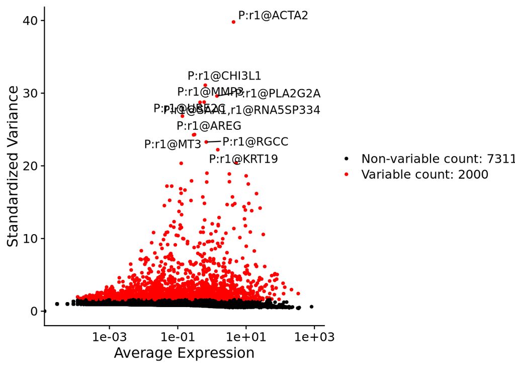

```r
plot2
```

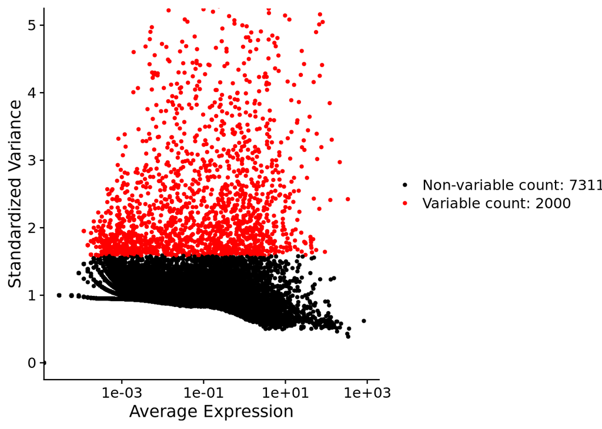

```r
plot1 + coord_cartesian(y=c(0,5))
```

```r
all.genes = rownames(sbs)
sbs = ScaleData(sbs, features=all.genes)
```

## PCA

If features=NULL, PCA will be run using the variable features for the Assay. Note that the features must be present in the scaled data. Any requested features that are not scaled or have 0 variance will be dropped, and the PCA will be run using the remaining features.

```r
var.feat = VariableFeatures(sbs)
for_pca = subset(sbs, features=var.feat)
for_pca = FindVariableFeatures(for_pca)
```

```
## Finding variable features for layer counts
```

```r
head(for_pca[["RNA"]][[]])
```

```
##                                       full_id              simple_id
## P:r1@AL669831.3                 P:r1@C1orf174          P:r1@C1orf174
## P:r1@SAMD11            P:r1@ADDG01001745809.F P:r1@ADDG01001745809.F
## P:r1@MMP23B            D:r1@ADDG01000530945.R D:r1@ADDG01000530945.R
## D:r1@ADDG01003619508.F D:r1@ADDG01008419287.F D:r1@ADDG01008419287.F
## P:r1@ERRFI1            D:r1@ADDG01006849998.F D:r1@ADDG01006849998.F
## P:r1@ENO1              P:r1@ADDG01023974973.F P:r1@ADDG01023974973.F
##                                gene_name proximity vf_vst_counts_mean
## P:r1@AL669831.3                 C1orf174         P         0.14367833
## P:r1@SAMD11            ADDG01001745809.F         P         0.12062612
## P:r1@MMP23B            ADDG01000530945.R         D         0.17722489
## D:r1@ADDG01003619508.F ADDG01008419287.F         D         0.04454205
## P:r1@ERRFI1            ADDG01006849998.F         D         1.78336232
## P:r1@ENO1              ADDG01023974973.F         P        15.11965333
##                        vf_vst_counts_variance vf_vst_counts_variance.expected
## P:r1@AL669831.3                     0.2957288                       0.5185345
## P:r1@SAMD11                         0.2731678                       0.4481755
## P:r1@MMP23B                         0.5234516                       0.6251355
## D:r1@ADDG01003619508.F              0.1267525                       0.1633491
## P:r1@ERRFI1                         7.5041840                      12.1424270
## P:r1@ENO1                         292.7364933                     488.8874269
##                        vf_vst_counts_variance.standardized
## P:r1@AL669831.3                                  0.5703165
## P:r1@SAMD11                                      0.6095108
## P:r1@MMP23B                                      0.8373410
## D:r1@ADDG01003619508.F                           0.7759607
## P:r1@ERRFI1                                      0.6180135
## P:r1@ENO1                                        0.5987810
##                        vf_vst_counts_variable vf_vst_counts_rank
## P:r1@AL669831.3                          TRUE               1885
## P:r1@SAMD11                              TRUE               1754
## P:r1@MMP23B                              TRUE               1068
## D:r1@ADDG01003619508.F                   TRUE               1216
## P:r1@ERRFI1                              TRUE               1721
## P:r1@ENO1                                TRUE               1794
##                                  var.features var.features.rank
## P:r1@AL669831.3               P:r1@AL669831.3              1885
## P:r1@SAMD11                       P:r1@SAMD11              1754
## P:r1@MMP23B                       P:r1@MMP23B              1068
## D:r1@ADDG01003619508.F D:r1@ADDG01003619508.F              1216
## P:r1@ERRFI1                       P:r1@ERRFI1              1721
## P:r1@ENO1                           P:r1@ENO1              1794
```

```r
for_pca
```

```
## An object of class Seurat
## 2000 features across 33923 samples within 1 assay
## Active assay: RNA (2000 features, 2000 variable features)
##  3 layers present: counts, data, scale.data
```

```r
for_pca = RunPCA(for_pca)
```

```
## Warning: Converting to a dense matrix may use excessive memory
## PC_ 1
## Positive:  P:r1@AKR1C2, P:r1@CYB5A, P:r1@CFD, P:r1@CIDEC, P:r1@FABP5, P:r1@FABP4, P:r1@DBI, P:r1@PNPLA2, P:r1@AKR1C1, P:r1@SCD
##     P:r1@FADS1, P:r1@RASD1, P:r1@G0S2, P:r1@PLAAT3, P:r1@FASN, P:r1@RPL41P1, P:r2@CIDEC, P:r1@ADDG0X023784085.F,r1@SAT1, P:r1@GPD1, P:r1@AOC3
##     P:r1@STOM, P:r1@PLIN1, P:r1@APOE, P:r1@NR1H3, P:r1@PRKAR2B, P:r1@AQP7, P:r1@ADH1B, P:r1@IGFBP5, P:r1@COL4A1, P:r1@INSIG1
## Negative:  P:r2@CALD1, P:r1@ISLR, P:r1@TPM1, P:r1@LOX, P:r1@TPM4, P:r1@PKM, P:r1@CTHRC1, P:r1@CREB3L1, P:r1@ACTG1, P:r1@CYTOR,r1@AC133644.3
##     P:r1@TAGLN, P:r4@ACTB, P:r1@ADDG0X002692186.B,r1@CD99, P:r1@TNFRSF12A, P:r1@TGFB1I1, P:r1@COL1A1, P:r1@TGFBI, P:r1@PDLIM7, P:r1@C12orf75, P:r1@MIR4435-2HG,r1@AC017002.1
##     P:r1@FLNA, P:r1@NREP, P:r1@THBS1, P:r1@TSPAN4, P:r1@SERPINE1, P:r1@ANXA5, P:r1@EFEMP2, P:r1@MYH9, P:r1@FHL2, P:r1@CTSB
## PC_ 2
## Positive:  P:r1@SNAI2, P:r1@MT1E, P:r1@CRISPLD2, P:r1@MT1X,r1@AC026461.1, P:r1@DCN, P:r1@C1orf21, P:r1@PNRC1, P:r1@IGFBP4, P:r1@SAMHD1, P:r1@MT2A
##     P:r1@SLC44A1, P:r1@ZFP36L1, P:r1@AOX1, P:r1@NNMT, P:r1@EDNRB, P:r1@CALD1, P:r1@FBLN1, P:r1@ADDG0X103686527.B,r1@ADDG0X103687946.B,r1@MORF4L2, P:r1@TGFBR2, P:r1@RPL41P1
##     P:r1@ADDG0X107715877.B,r1@TSC22D3, P:r1@CRLF1, P:r1@CUL4B, P:r1@CEBPD, P:r1@SH3PXD2B, P:r1@HSD11B1, P:r1@COPS8, P:r1@LMO3, P:r1@TMEM45A, D:r1@ADDG08048920646.R
## Negative:  P:r1@AGPAT2, P:r1@ADIPOQ, P:r1@CDKN2C, P:r1@ADIRF, P:r1@THRSP, P:r1@GPD1, P:r1@AQP7, P:r1@RBP4, P:r1@MYL9, P:r1@PRKAR2B
##     P:r1@CHCHD10, P:r1@PLIN1, P:r1@LGALS12, P:r1@SCD, P:r1@HADH, P:r1@CAMK1, P:r1@LIPE, P:r1@MEST, P:r1@DLAT, P:r1@PNPLA2
##     P:r1@NR1H3, P:r1@DGAT2, P:r1@ACSF2, P:r1@DBI, P:r1@TM7SF2, P:r1@ACACB, P:r1@GPAM, P:r1@AQP7P1, P:r1@MKNK2, P:r2@PRXL2A
## PC_ 3
## Positive:  P:r1@RRM2, P:r1@BIRC5, P:r1@ANLN, P:r1@PRC1, P:r1@CCNA2, P:r1@MKI67, P:r1@TK1, P:r1@NUSAP1, P:r1@CENPF, P:r1@TPX2
##     P:r1@CEP55, P:r1@LMNB1, P:r1@CENPM, P:r1@CDCA3, P:r1@CDC20, P:r1@SHCBP1, P:r1@UBE2C, P:r1@CCNB2, P:r1@DLGAP5, P:r1@KIFC1
##     P:r1@DEPDC1, P:r1@NDC80, P:r1@GTSE1, P:r1@CCNB1, P:r1@NCAPG, P:r1@KIF23, P:r1@PBK, P:r1@DIAPH3, P:r1@PLK1, P:r1@ASPM
## Negative:  P:r1@ITGA11, P:r1@EPSTI1, P:r1@MFAP4, P:r1@BGN, P:r1@SOD2, P:r1@THBS2, P:r1@GREM1, P:r1@DACT1, P:r1@CDH11, P:r1@TPD52L1
##     P:r1@JUNB, P:r1@TNFAIP6, P:r1@KIF26B, D:r1@ADDG01245860738.R, P:r1@MFAP2, P:r1@SFRP4, P:r1@FBLN2, P:r1@CH25H, P:r1@TNFAIP2, P:r1@NREP
##     P:r1@IER3, P:r1@HMCN1, P:r1@SPARC, P:r1@C3, P:r1@ATF5, P:r1@FAP, P:r1@CCL2, P:r1@COL3A1, P:r1@CCN5, P:r1@FIBIN
## PC_ 4
## Positive:  P:r1@PSAT1, P:r1@SLC3A2, P:r1@MTHFD2, P:r1@ASNS, P:r1@HSPA5, P:r1@HYOU1, P:r1@SDF2L1, P:r1@MANF, P:r1@HSP90B1,r1@MIR3652, P:r1@DNAJB11
##     P:r1@HERPUD1, P:r1@CDK2AP2, P:r1@TRIB3, P:r1@PCK2, P:r1@DNAJB9, P:r1@GDF15,r1@MIR3189, P:r1@CHAC1, P:r1@CALR, P:r1@ADDG0X103686527.B,r1@ADDG0X103687946.B,r1@MORF4L2, P:r1@DDIT4
##     P:r1@PDIA4, P:r1@NEDD4, P:r1@ATF5, P:r1@DDIT3,r1@AC022506.1, P:r1@RGS2, P:r1@GARS, P:r1@ARHGEF19, P:r1@ALOX15B, P:r1@WARS, P:r1@PDLIM1
## Negative:  P:r1@CXCL12, P:r1@S100A4, P:r1@S100A10, P:r1@CLU, P:r1@DCN, P:r1@IGFBP6, P:r1@PLPP3, P:r1@ADDG0X047581818.F,r1@ADDG0X047583314.F,r1@TIMP1, P:r1@NT5E, P:r1@FBLN1
##     P:r1@IFITM1, P:r1@CRIP1,r1@AL928654.3, P:r1@CRLF1, P:r1@MFAP5, P:r1@CRABP2, P:r1@PROCR, P:r1@GSN, P:r1@CLDN11,r1@AC026316.4, P:r1@CTSK, P:r1@TIMP3
##     P:r1@CYP1B1, P:r1@CXCL6, P:r1@CXCL1, P:r1@SCARA3, P:r1@SH3BGRL3, P:r1@LSP1, P:r1@COLEC12, P:r1@CFD, P:r1@CBR3, P:r1@CLEC3B
## PC_ 5
## Positive:  P:r1@CCN5, P:r1@CXCL6, P:r1@C3, P:r1@TNFAIP6, P:r1@CXCL1, P:r1@CFB, P:r1@EPSTI1, P:r1@CXCL2, P:r1@FAM20C, P:r1@CXCL3
##     P:r1@OLFML2B, P:r1@ATF5, P:r1@FAM20A, D:r1@ADDG04073721039.R, P:r1@MFAP4, P:r1@SOD2, P:r2@SLC39A8, P:r1@FAP, P:r1@CXCL5, P:r1@ADIPOQ
##     P:r1@CHI3L1, P:r1@GPNMB, P:r1@COL14A1, P:r1@TNFAIP2, P:r1@THRSP, P:r1@SFRP4, P:r1@RBP4, P:r1@DDIT3,r1@AC022506.1, P:r1@GDF15,r1@MIR3189, P:r1@AGT
## Negative:  P:r1@ACTA2, P:r1@S100A10, P:r3@FHL1, P:r2@FLNA, P:r1@CNN1, P:r1@MFAP5, P:r1@TIMP3, P:r1@CSRP1, P:r1@THY1, P:r1@HSPB1
##     P:r1@MYADM, P:r1@DDAH1,r1@AC092807.2,r1@AC092807.3, P:r1@IGFBP5, P:r1@LMOD1, P:r1@KRT7, P:r4@ACTB, P:r1@F3, P:r1@MT1X,r1@AC026461.1, P:r1@KRT18, P:r1@MT1L
##     D:r1@ADDG07005527461.B, P:r1@MT2A, P:r1@LIMS2, P:r2@PDLIM2, D:r1@ADDG02036544419.R, P:r1@PDK4, P:r1@HSD11B1, P:r1@LDHA, P:r1@LMO7, P:r1@GSN
##
## This message is displayed once every 8 hours.
```

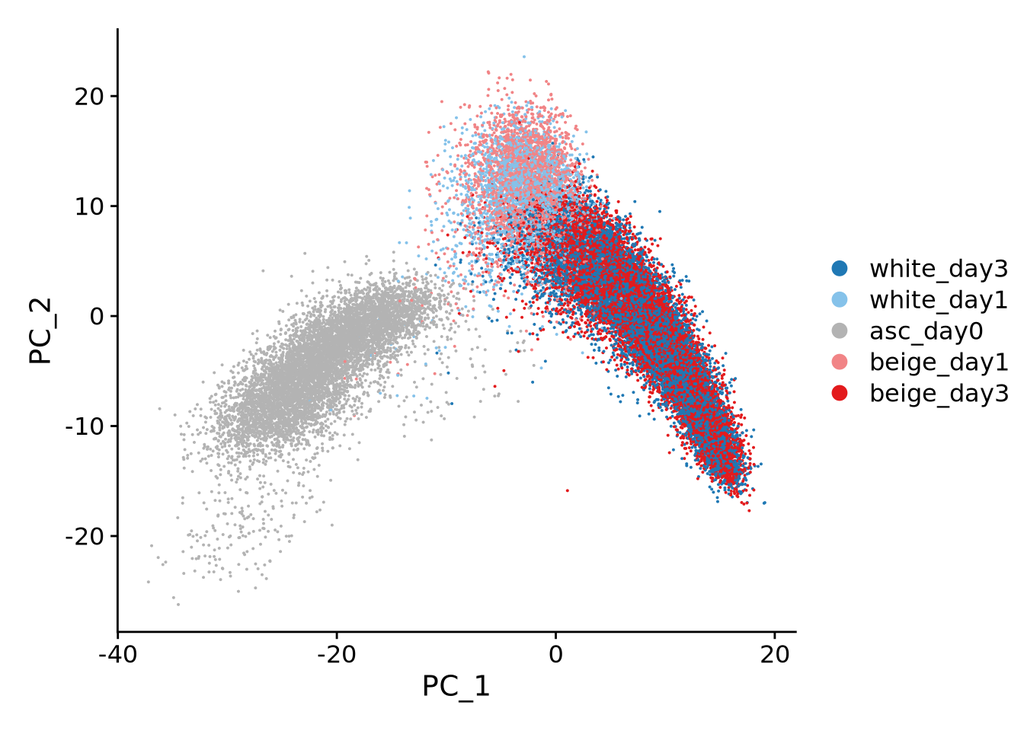

```r
DimPlot(for_pca,shuffle = T, cols = pal)
```

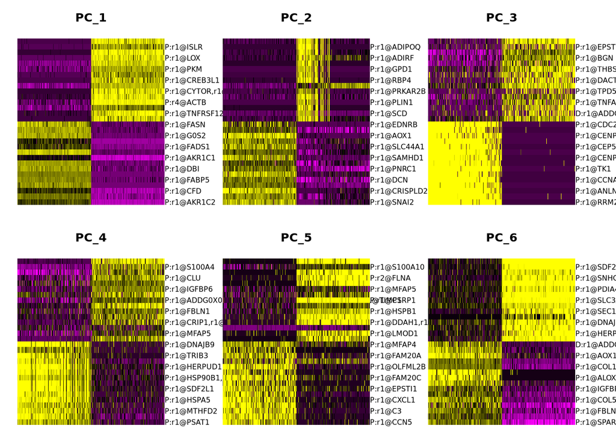

```r
DimHeatmap(for_pca, dims = 1:6, cells = 500, balanced = TRUE)
```

```r
for_pca[["pca"]]
```

```
## A dimensional reduction object with key PC_
##  Number of dimensions: 50
##  Number of cells: 33923
##  Projected dimensional reduction calculated:  FALSE
##  Jackstraw run: FALSE
##  Computed using assay: RNA
```

```r
sbs[["pca"]] = for_pca[["pca"]]
```

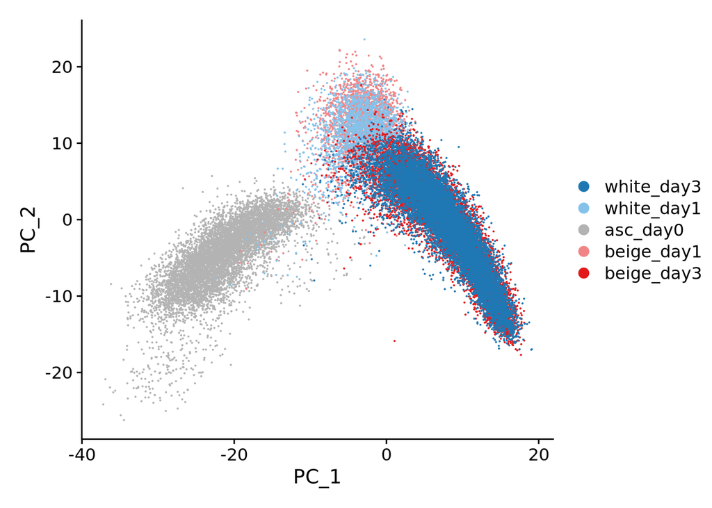

```r
DimPlot(sbs, reduction = "pca", cols = pal)
```

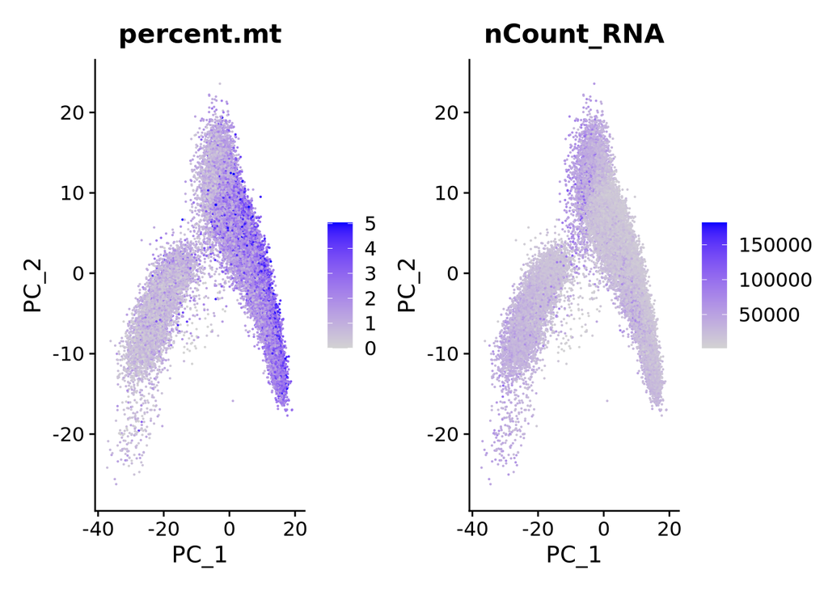

```r
FeaturePlot(sbs, features= c("percent.mt","nCount_RNA","CHI3L1","ACTA2"))
```

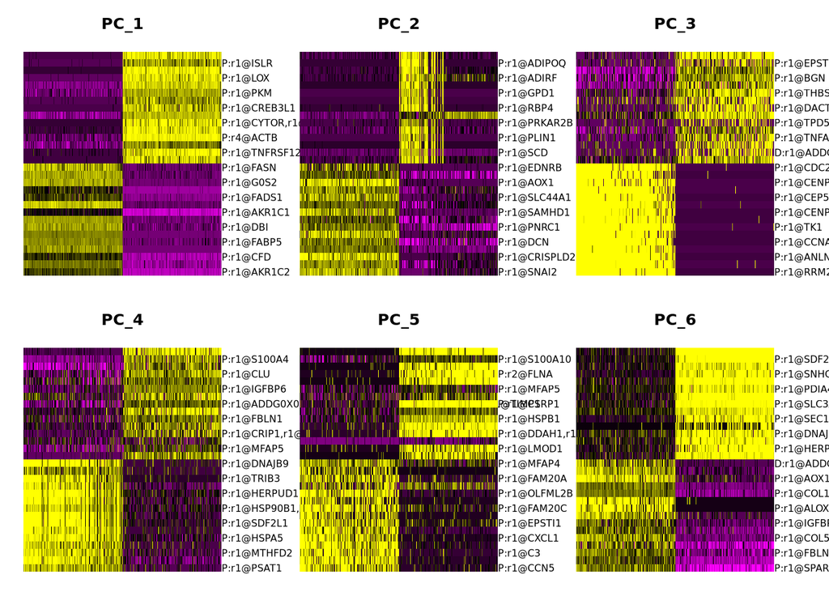

```r
DimHeatmap(sbs, dims = 1:6, cells = 500, balanced = TRUE)
```

## Determine the dimensionality

They encourage to complete downstream analyses with different numbers of PCs.

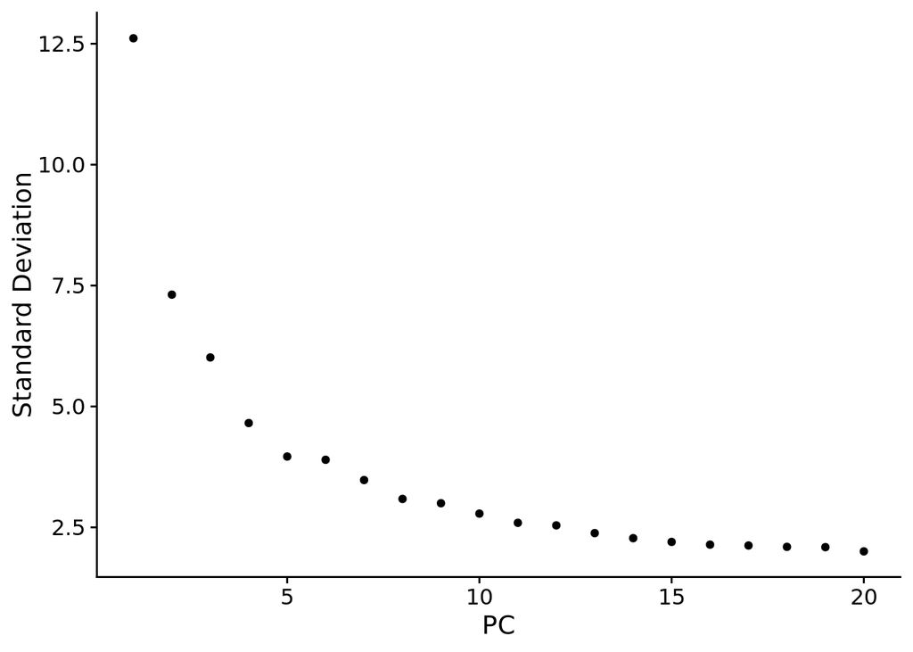

```r
ElbowPlot(sbs, ndims = 20)
```

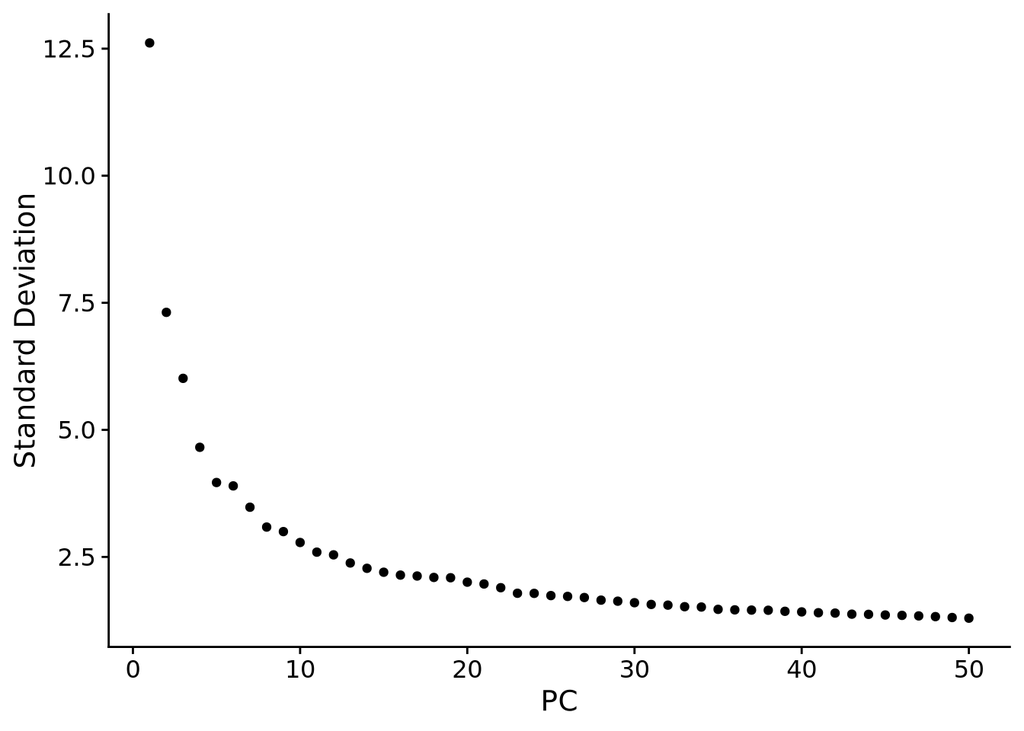

```r
ElbowPlot(sbs, ndims = 50)
```

## Cluster

```r
sbs <- FindNeighbors(sbs, dims = 1:30)
sbs <- FindClusters(sbs, resolution = 0.5)
```

```
## Modularity Optimizer version 1.3.0 by Ludo Waltman and Nees Jan van Eck
##
## Number of nodes: 33923
## Number of edges: 1006672
##
## Running Louvain algorithm...
## Maximum modularity in 10 random starts: 0.8755
## Number of communities: 12
## Elapsed time: 9 seconds
```

```r
table(sbs@meta.data$seurat_clusters)
```

```
##
##    0    1    2    3    4    5    6    7    8    9   10   11
## 6897 6859 6456 4484 3845 2877 1423  361  318  242   93   68
```

## Cluster composition

```r
composition = group_by(sbs@meta.data, orig.ident,seurat_clusters) %>% count()
composition = composition[order(composition$n, decreasing = T),]
colnames(composition) = c("orig.ident","seurat_clusters","n_cells")
head(composition)
```

```
## # A tibble: 6 × 3
## # Groups:   orig.ident, seurat_clusters [6]
##   orig.ident seurat_clusters n_cells
##   <fct>      <fct>             <int>
## 1 asc_day0   1                  6859
## 2 beige_day3 0                  3530
## 3 white_day3 0                  3315
## 4 white_day3 2                  3303
## 5 beige_day3 2                  3147
## 6 beige_day1 3                  2236
```

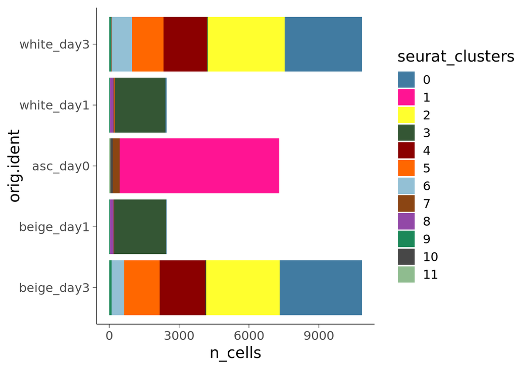

```r
ggplot(composition) + geom_bar(stat="identity",aes(y=orig.ident, x=n_cells, fill=seurat_clusters)) +
  scale_y_discrete(limits=rev) + scale_fill_manual(values=clusters)
```

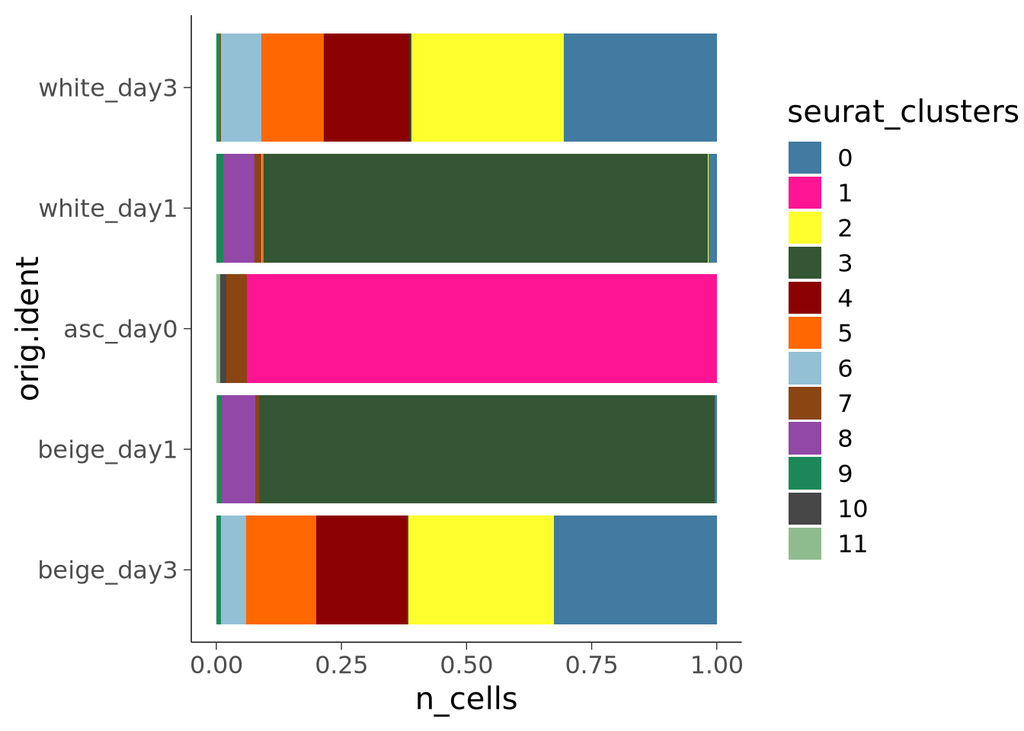

```r
ggplot(composition) + geom_bar(stat="identity",aes(y=orig.ident, x=n_cells, fill=seurat_clusters), position = "fill") +
  scale_y_discrete(limits=rev)+ scale_fill_manual(values=clusters)
```

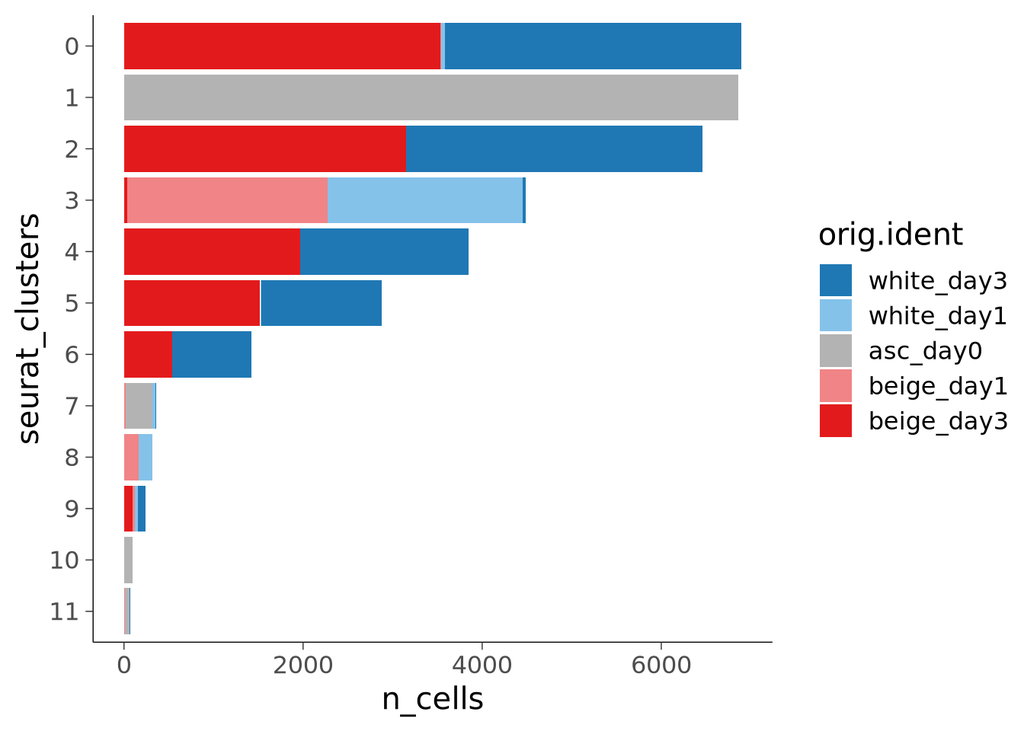

```r
ggplot(composition) + geom_bar(stat="identity",aes(fill=orig.ident, x=n_cells, y=seurat_clusters)) +
  scale_y_discrete(limits=rev)+ scale_fill_manual(values=pal)
```

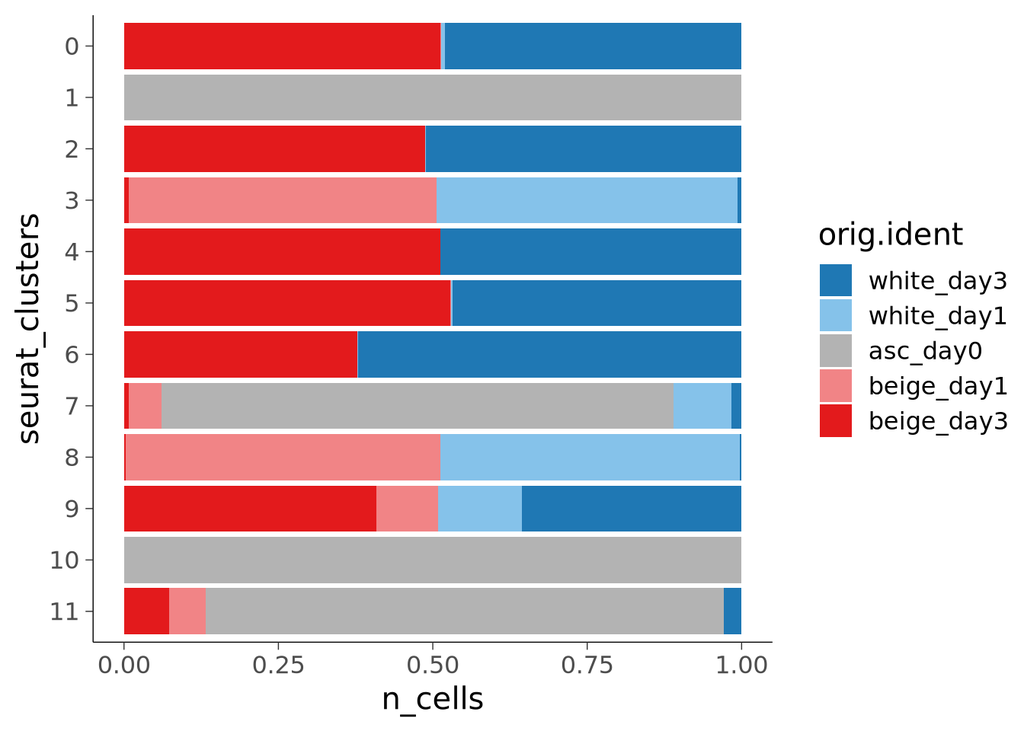

```r
ggplot(composition) + geom_bar(stat="identity",aes(fill=orig.ident, x=n_cells, y=seurat_clusters), position = "fill") +
  scale_y_discrete(limits=rev) + scale_fill_manual(values=pal)
```

## UMAP

```r
sbs = RunUMAP(sbs, dims=1:30)
```

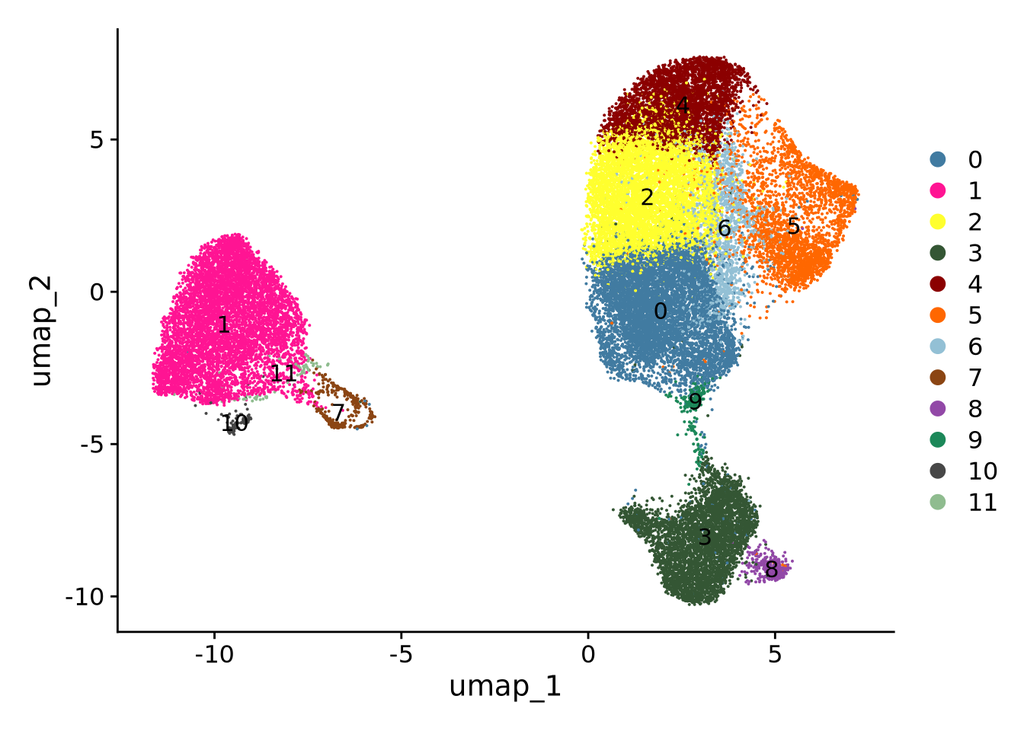

```r
DimPlot(sbs, reduction="umap", label=T, shuffle = T, cols=clusters)
```

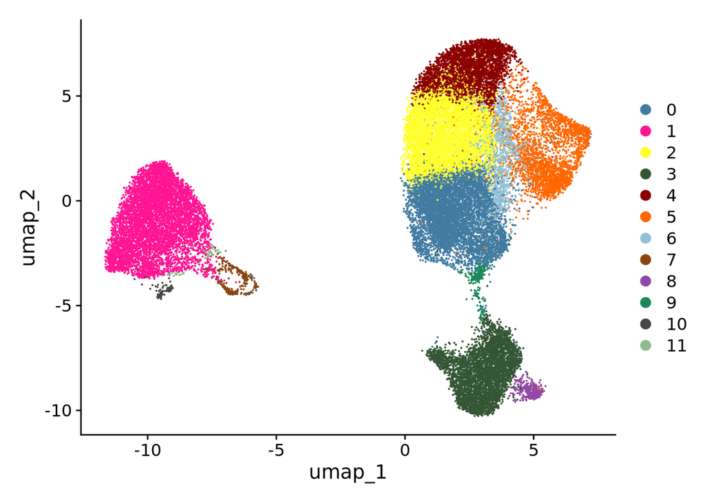

```r
DimPlot(sbs, reduction="umap", label=F, shuffle = T, cols=clusters)
```

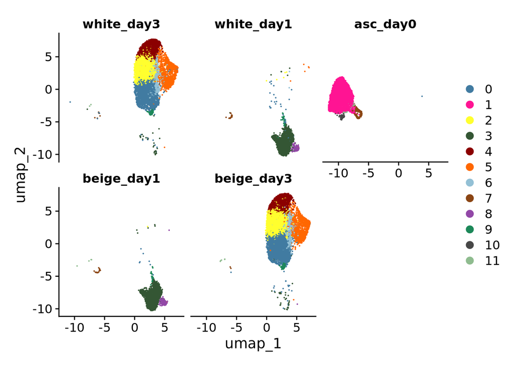

```r
DimPlot(sbs, reduction="umap", split.by = "orig.ident", ncol=3, shuffle = T, cols=clusters)
```

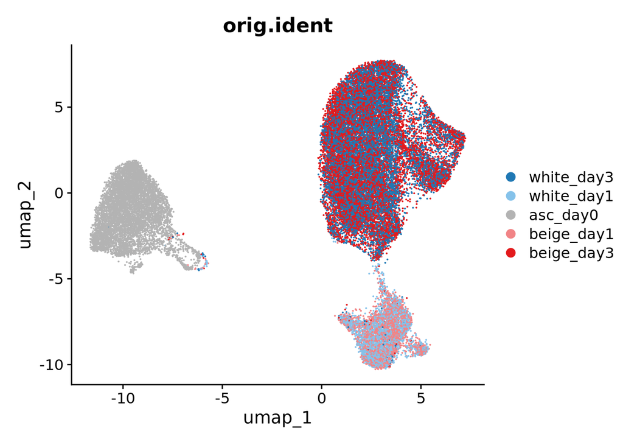

```r
DimPlot(sbs, group.by="orig.ident", cols=pal, shuffle = T)
```

## t-SNE

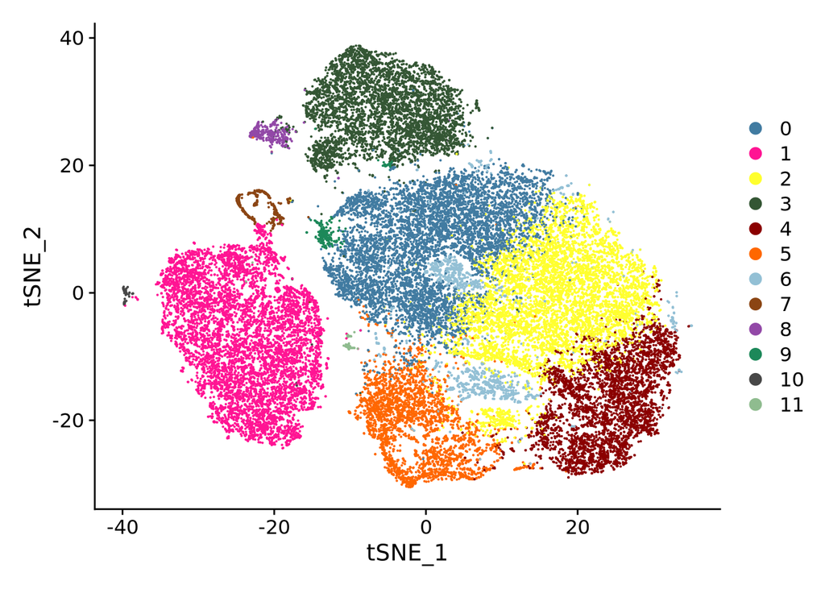

```r
sbs = RunTSNE(sbs, reduction="pca", dims=1:30)
DimPlot(sbs, reduction = "tsne",shuffle=T, cols=clusters)
```

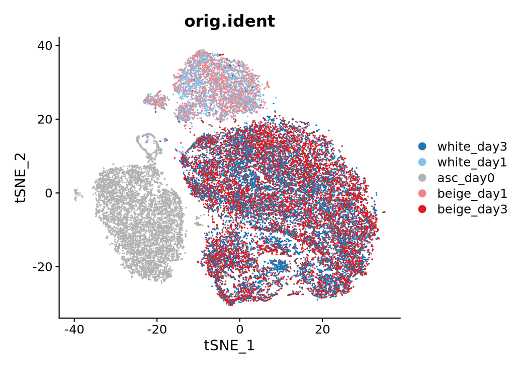

```r
DimPlot(sbs, reduction = "tsne", group.by= "orig.ident", shuffle = T, cols=pal)
```

## Find biomarkers

Min.pct sets the minimum percentage of cells for a marker to be found in

Does densify, which increases speed at the cost of memory help?

```r
norm.markers = FindAllMarkers(sbs, only.pos = T, min.pct=0.25,
                              logfc.threshold = 0.5, densify=T)
norm.markers = merge(norm.markers,
                     sbs[["RNA"]][[c("simple_id","gene_name","proximity")]],
                     by.x="gene", by.y="simple_id")
norm.markers = arrange(norm.markers, p_val_adj, avg_log2FC)
head(norm.markers); dim(norm.markers)
```

```
##                        gene p_val avg_log2FC pct.1 pct.2 p_val_adj cluster
## 1                P:r1@PSMA6     0  0.5002580 0.998 0.958         0       3
## 2               P:r1@TMED10     0  0.5020673 0.988 0.948         0       1
## 3               P:r1@ATP5ME     0  0.5024550 0.998 0.983         0       4
## 4                 P:r1@CYBA     0  0.5029189 0.971 0.902         0       1
## 5               P:r1@ANP32B     0  0.5072504 0.984 0.940         0       1
## 6 P:r1@COX6A1,r1@AL021546.1     0  0.5092456 1.000 0.998         0       4
##              gene_name proximity
## 1                PSMA6         P
## 2               TMED10         P
## 3               ATP5ME         P
## 4                 CYBA         P
## 5               ANP32B         P
## 6 COX6A1,r1@AL021546.1         P
```

```
## [1] 16799     9
```

```r
top.markers = as.data.frame(norm.markers %>%
    group_by(cluster) %>%
    slice_max(n = 2, order_by = avg_log2FC))
top.markers
```

```
##                      gene         p_val avg_log2FC pct.1 pct.2     p_val_adj
## 1             P:r1@SCARA5  0.000000e+00   2.105895 0.353 0.122  0.000000e+00
## 2                P:r1@MGP 3.544707e-221   1.918522 0.653 0.526 2.662678e-216
## 3               P:r1@WNT2  0.000000e+00   6.635500 0.464 0.009  0.000000e+00
## 4              P:r1@CEMIP  0.000000e+00   6.326458 0.409 0.012  0.000000e+00
## 5               P:r1@UCP2  0.000000e+00   1.868019 0.850 0.330  0.000000e+00
## 6             P:r1@GPBAR1  0.000000e+00   1.863962 0.469 0.144  0.000000e+00
## 7            P:r1@ALOX15B  0.000000e+00   5.794095 0.460 0.016  0.000000e+00
## 8  D:r1@ADDG09116267342.F  0.000000e+00   5.068932 0.325 0.010  0.000000e+00
## 9               P:r1@PCK1  0.000000e+00   5.079609 0.443 0.026  0.000000e+00
## 10               P:r1@GPT  0.000000e+00   4.294348 0.414 0.030  0.000000e+00
## 11             P:r1@DERL3  0.000000e+00   5.862050 0.363 0.014  0.000000e+00
## 12            P:r1@SDF2L1  0.000000e+00   3.008592 0.852 0.498  0.000000e+00
## 13        P:r1@AL669831.3  0.000000e+00   4.087737 0.505 0.086  0.000000e+00
## 14 P:r2@ADDG02038482405.B 1.510655e-176   2.814405 0.323 0.103 1.134759e-171
```

[output cut: 35 more lines]

Visualisation methods

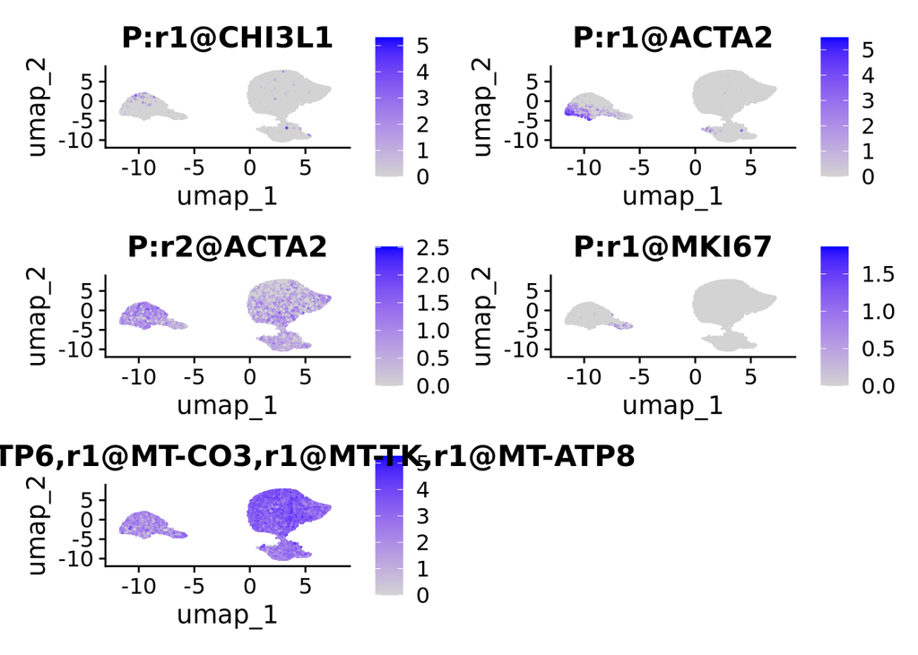

```r
to_plot = grep("ACTA2|MKI67|MT-ATP8|CHI3L1", value=T, Features(sbs))

FeaturePlot(sbs, features =to_plot)
```